# 《社会科学家的写作》中的窍门

Writing for Social Scientists

How to start and finish your thesis, book, or article

Howard S. Becker & Pamela Richards

窍门整理：[王成军](https://chengjun.github.io/)

我相信我所偏好的条理清晰和直截了当之类的特征同样植根于社会学的符号互动的传统。

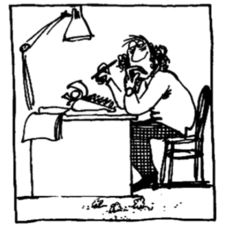

1. Freshman English for Graduate Students 1
2. Persona and Authority 26
3. One Right Way 43
4. Editing by Ear 68
5. Learning to Write as aProfessional 90
6. Risk, by Pamela Richards
7. Getting It out the Door 121
8. Terrorized by the Literature 135
9. Writing with Computers 150
10. A Final Word 173

# 第一章 大一英语水平的研究生

贝克尔：我甚至没有备课，因为我不知道怎么去教这门课。

第一节课，提问：你是怎么写作的？写作习惯有哪些真实的细节？

- 打字机还是手写
- 特殊的纸张
- 特殊的时间段

这些症状是具有魔力的仪式。

人们进行这类仪式来影响那些他们觉得没有理性手段可以控制其进程的结果。Malinowski, 1948, p 25-36.

- 巫术
- 抽烟
- 喝酒

这门课强调的不是写作，而是编辑和改写。

- 因此，要获得选这门课的许可，必须要有一篇已经写好的论文，以便他们现在可以用来练习改写。

### 窍门：一起动手改写。

第二节课：我们一起花了3个小时来进行改写

- 我们大部分时间都是在删除冗余的字
- 我把铅笔放在一个字或短语上，并问道：这个需要放在这里吗？如果不需要，我就要把它拿掉了。
- 没有人要求保留某个字或短语，我就把它拿掉。
- 我把被动句改成主动句。
- 把一些句子整合起来，又把长句子断开。

我的手稿在出版之前一般都熬改写8到10遍。

这个练习带来好几个结果。学生们心力交瘁，他们以前从来没有花费过这么多时间、如此细致地看一篇文章，也没有想过有人会在这么一件事情上花这么多时间。

- 任何能够被简化并且丝毫不会损害思想内容的东西都应当被删除。
  - the way in which --> how
- 那些冗长的表述中有一些无法被替代，因为它们根本没有意义被替代。

大学生没有时间来改写，因为它们经常是同时有好几篇论文要赶着交上去。

- 我给他们布置作业来使他们放弃那种一稿写成论文的方式。
- 我对学生们说：你们在第一稿当中无论写什么都差别不大，因为你可以一直对它进行改写。直到最后一稿才会一锤定音。
- 他们对自己的论文需要那么多修改以及人们怎么会在论文里犯那么多低级错误感到非常意外。

### 窍门：初稿可以随便写，不要有心理负担！

> 我说他们真的可以在一开始随便写什么，无论什么样的初稿，不管有多么粗糙和混乱，最终都可以将它修改成像样的东西。

### 窍门：摘录和列大纲

我们花了不少气力才找到一个愿意尝试这样一个冒险过程（贡献自己的初稿让大家一起修改）的人。

- 作者在讨论她的主题时七拐八绕，不确定自己想要说些什么，用几种不同的方式反复说同一件事情。
- 进行摘录是一个办法，先看看它包含了哪些内容。
- 然后为另一稿列出大纲。
- 回头再编辑比边改边编辑要好。

写作不是一蹴而就的，它可以分为几个阶段，每一个阶段都有着各自定义的优秀的标准。

- 写作实际上遵循着一个更为漫长的吸收和发展观点的程序。
- 每一个选择都影响着最终的结果。
  - 选哪个观点、使用什么词汇、用什么顺序、引用哪些作者、引用哪些文献

当你坐下来写作的时候，已经做出了很多选择，但你可能并不知道它们是些什么。

- 自然，这就造成一些疑惑，使得初稿内容混乱。
- 但一份内容混乱的草稿并不是让人让人羞愧的理由。
- 相反，它向你展示了你心系哪些想法、理论观点和结论。
- 当你知道自己还会写很多遍草稿时，你就该知道自己不必担心这一稿的粗糙和缺乏异质性。
- 这一稿仅仅是用于发现，而不是用于提交。

### 窍门：在研究早期就开始写作有助于确定研究设计

如果你在研究的早期阶段就开始写作——比如，在你掌握了所有数据之前——你能够更快地清理自己的思路。

- 没有数据就开始写草稿，会让你想要讨论什么显得更为清晰，因此也会让你更加明白自己必须要得到什么样的数据。因而，写作可以决定你的研究设计。
- 让文章更清晰，这实际上已经把读者考虑进来。

### 窍门：请信赖的人对初稿提意见。

- 互惠性
- 有时候觉得被审稿人骂也是活该呀，要多读几遍再提交。
- 被批评了怎么办？也去批评别人。常打架的人知道下手轻重。知道哪些是瞎批评，哪些是金玉良言。https://douc.cc/1nfeJY
- 社会互动：两个合作者一起讨论审稿意见可以降低心理压力、理清思路。

### 窍门：当审稿人给出矛盾的建议时，应首先去除论文中的混淆之处。

- 读者并没有洞察力。因此，当一个作者的论文含混不清或让人困惑时，读者不仅无法领会文章真正的意思，还会产生自己的解读，有时候这种解读甚至是与作者原意相反的解读。
  - 有些人做不到以正确的方式阅读文章。他们执着于一些小事情，也物理去思考或评论任何其他事情。
  - 另外有一些人，通常被更宽泛地认为是优秀编辑的那些人，则能看到核心问题并提出有用的意见

### 窍门：没有人lead的论文往往无疾而终。

一个实验：我提议大家一起就一个我们都知道的题目写一篇文章：社会学写作中的问题。我们采用一种古老的游戏形式，轮流来决定论文的下一句改写什么。

- 游戏结束时，我们一共写了18个句子。
- 学生争论谁将在最终稿上署名。
- 我们继续讨论，发现只有四五个学生真正对这件事有兴趣。
- 课程结束后，他们从来没有去写那篇论文。

# 第二章 人物角色和权威

“我并不很确定有什么规则主导着我的编辑行为，我只是根据耳朵进行编辑。”

问题：我们的文章为什么写得很啰嗦，也很有学究气？

问题：文雅的写作究竟是指什么？为什么学究气的写作方式更文雅？

### 窍门：追求成为学术权威导致学究式写作

学术精英主义：在一个高度等级化的机构里一个下级人士的看法。

- 对地位的渴求
- 维护精英团体的门槛
- 表明对科学共同体、理论、政治的忠诚
- 专业化：不用平实的语言来表现他们好不容易得来的知识————> 疯狂的怪圈！

坦克式的论文：密集的细节知识把读者轰晕了头，他们感觉只能接受作者的观点。

权威性只对不熟悉这个领域的读者起作用。

# 第三章 那个所谓正确的方法

### 窍门：考试心态扼杀了学生追求卓越的精神。

问题：为什么对改写持有如此疑虑的态度？

- 大学的教学体系通常是教本科生们去获取分数，而不是教他们对他们所学的课题产生兴趣或在一件事情上做得很出色。
- 考试心态：一次就做对、一次就写好的能力显示了超强的能力。

一个骗人的前提：总有正确答案或最佳做法。

从来不存在单一的正确的答案！

绝大多数学校把学术研究和教学分开的做法，让学生逐渐变得对这个过程（重写和编辑）一无所知。

- 学生们从来看不到老师写作时的样子，更不要说看到教科书作者们那么做的情形了
- 因此，他们并不知道这些人都是把文章改了很多遍的。
- 我们必须把自己从那种认为只有一种正确方式的观念中解放出来。

### 窍门：最后写导语！

埃弗雷特·休斯（Everett Hughes): 把引言部分放到最后来写！

导语是用来介绍的。你怎么能去介绍那些你还没写出来的东西呢？

- 导语显示了作者打算陈诉给读者的内容概貌，使读者可以把论点中的任一部分和文章的总体结构相连接。
- 读者有了这样一个地图，就很少会感到迷惑不解或不知所云。

练习：列出100个论文题目

### 窍门：拥抱混乱，动手写作！

不管我们如何开头都不会有什么区别。我们老早就已经选定了自己的路径和目的地。

提纲会有所帮助，但如果你用它们作为起点的话，就没什么用处了。

记住：

- 每个句子都是可以改动、重写、删除或者被否定的。
- 这可以使你完全随心所欲地去写。
- 无论你脑子里想到什么，都把它写下来，用你最快的打字速度。
- 不要去参考什么提纲、笔记、数据、书籍或者任何其他的辅助资料
- 其目的是为了发现你想要说的话，发现在所有那些你先前对这个题目或项目所做的工作中得到的观点。
- 一旦你把自己的想法写下来，大部分内容只会在很少一些主题上有轻微的变动。
- 你的确知道自己想要说些什么。

### 窍门：把想法说出来、录下来

大多数人会发现：一直说下去并且在录音版本上进行修改更为容易些。

先从最容易的做起:

- 先写最容易些的部分，做一些简单的事务。
  - 比如，整理论文
- 对写下的东西进行摘录、把每一个想法都记录在文档卡片上
  - 不要丢弃草稿中任何一个想法，它们迟早会有用，你的潜意识知道自己并不清楚的事情
- 把卡片整理归类并进行概括
- 排列卡片

使用**思维导图**或**逻辑流程图**对整理想法是有用的！

### 窍门：把学术写作看作是整理田野笔记

- 我们自己的大脑是一个未知的田野
- 写作是一种认识自我的方式

P.S. 摘录卡片的思路正是定性研究编码-重新编码的方法。

### 窍门：谈论那些无法解决的问题

- 你无须去解决那些不能解决的问题
- 但可以只是谈论它
  - 向读者解释为什么它会是一个问题。
    - 把它作为一个分析焦点。
    - 它可能帮助我们找到解决方案！
    - 承认自己有过这些麻烦，让读者接受你对于解决这些麻烦的信心。
  - 解释为什么实际选择并不完美的方法
  - 这种方法意味着什么？

小老虎丹尼尔：when we do something new, let's talk about what we do!

[figure not shown]

# 第四章 用耳朵进行编辑

写八股文不是那么机械的，同样需要创造力！

### 窍门：阅读专业领域之外的文章，选择好的范例

自我训练得几乎能够自动使用学到的写作规则：

- 我会习惯性地寻找被动语态
- 我明白我在做什么
- 可以说出相关原则
- 依赖自己的耳朵做出判断

问题：为什么不在第一次修改的时候就改好呢？

- 每一次改动都为其它修改带来可能
- 当你清楚没用的词汇和短语时，你能更清楚地看清句子的意思
- 并能使用更简洁、更精确的短语来表达
1. 主动语态、被动语态
2. 减少用词
3. 重复
4. 结构、内容：陈述身份、描述特点、陈述因果、加强论点
5. 具体的、抽象的：最能让读者信服我们研究结果的普遍性的方法是用具体的细节描述研究。
   - 使用具体的细节让事情在读者眼中更生动、记忆更深刻
   - 把冗长的句子压缩为简练的句子时，让松散的观点顿时紧凑、清晰、精确
6. 隐喻：删除廉价的隐喻、创造更有效的隐喻、更认真的使用隐喻。
   - 使用隐喻是一项非常严肃的理论性练习
   - 隐喻表明不同的经验性现象属于一个一般化的类型，后者暗含着一个理论！

To begin, consider the following paragraph, which discusses the strategy of describing social groups through photographic portraits of their members:

> Whatever part they [photographers] let stand for the person, the strategy implies a theory and a method. The theory is a simple one, but it is important to make its steps explicit, so that we can see how it works. The theory is that the life a person has lived, its good times and bad, leaves its marks. Someone who has lived a happy life will have a face that shows that. Someone who has managed to maintain their human dignity in the face of trouble will have a face that shows that. . .. This is a daring strategy, because it makes the little that the photograph does contain carry an enormous weight. We must, if the theory is to work and help us to produce effective images, choose faces, details of them, and moments in their history which, recorded on film and printed on paper, allow viewers to infer everything else they are interested in. Viewers, that is, look at the lines on a face and infer from them a life spent in hard work in the sun.

**The theory is a simple one, but it is important to make its steps explicit, so that we can see how it works.**

- If it's important to do it, don't talk about it, do it.
- I first changed **"it is important to"** to **"we need to."**
  - That made the sentence more active, and slightly stronger, and introduced an agent, someone actually doing it.
  - Things that are not done by anyone, but "just are," have a fuzzy quality I don't like.

I still wasn't happy. The sentence had three clauses which were just strung together. If I can rearrange a sentence so that its organization displays and thus reinforces the connections I am describing, I do.

- So I cut the first clause, putting its content into an adjectival phrase.
- Instead of saying the theory was a simple one, I replaced "its steps" in the second clause with "the steps of this simple theory."
- A few words less, and the simplicity of the theory reduced to a small descriptive point: **"We need to make the steps of this simple theory explicit. ..."**
  - Having done it, I no longer had to say that we needed to do it, which was no better than saying it was important to do it.
- The rewritten sentence reads, **"If we make the steps of this simple theory explicit, we can see how it works."**
  - It has sixteen words instead of twenty-three. The three strung-together clauses now make an if-then argument that is more interesting than the list it replaced.

- I changed **"Someone"** to **"People"** for no very good reason,
  - mainly because I wanted to get at "managed to maintain."
  - Wordy phrases like "manage to maintain" try to make simple statements sound profound.
- Talking about people's ability to act evokes the academic urge to profundity.
  - It seems trivial to say that people "can" do something.
  - We prefer to say that they **"had the capability of"** or **"the ability to"** or even, striving for simplicity, that they **"were able to"**
- I almost invariably use such constructions in early drafts and replace them with "can" when I rewrite. So I challged the sentence to **"People who have kept ..."**

Finally, consider the sentence about lines on a face: **"Viewers, that is, look at the lines on a face and infer from them a life spent in hard work in the sun."**

- I cut some words that weren't doing much work.
- I proved that **"that is"** was meaningless by taking it out and seeing that the sentence lost no meaning.
- Applying the same test, I changed **"a life spent in hard work"** to a **"life of hard work."**
- But I also saw a way to add a few words and make the image more concrete: **"Viewers look at the lines on a face and infer that they were baked in during a life of hard work in the sun."**
- A slight transposition remedies the ambiguity of "they" and reads even better: **"Looking at the lines on a face, viewers infer that ..."**

Whatever part a photographer chooses to stand for the person, he or she is employing a strategy that relies on a theory and a method. This strategy depends on the assumption that the experiences of life are recorded in faces, that the life a person has lived leaves physical marks.

Photographers, accordingly, choose faces, details of faces, and moments in their histories which, recorded on film and printed on paper, allow viewers to deduce what they don't see but want to know about. Portraits often contain a wealth of detail, so that careful study allows us to make complex and subtle readings of the character of the person and of the life-in-society of that person. Looking at the lines on a face, viewers may conclude that that these were baked in during a life of hard work in the sun. From these same lines, they can infer wisdom produced by hard work and age or, alternatively, senility and decay. To make any of these conclusions, a viewer must bring to bear on the image one of several possible theories of facial lines.

### 窍门：大胆地写草稿，挑剔地改文章

> 你飞快的毫不在意地写下第一版草稿，因为你知道自己随后会很挑剔。

# 第五章 学会像一个专业人士那样写作

> 在（芝加哥学派）那个传统和环境中的成长让我有了一种理论上的傲慢，一种自我陶醉的罪过。

首要的一点，没有人能一夜之间学会写作。相反，学习始终贯穿于职业生涯。

> 我1951年在芝加哥大学获得哲学博士学位，那年23岁。只找到一个研究大麻使用的工作。圣诞节期间，有轨电车翻到在一辆小汽车上。小汽车司机是芝加哥大学社会科学2这门课的教师之一，他们亟需找人替代。认识了马克·本尼（Mark Benney）

马克说：我想你只能按照那种可笑的风格来写！

- 这样的评论刺痛了我

休斯在凌晨四点写编辑评语给我“臣服！陈腐！陈腐！

- 加强了我的决心：要写出条理清晰、易于理解的文章，听起来就是原滋原味的英语。

### 窍门：把改写当成填字游戏

- 对我们草稿中的每个单词都进行认真推敲
- 问题不在于用哪个词正确，而在于我们想要说什么。
- 改写是件好玩的事情：就像猜字谜游戏
  - 要点在于找到一种简约的方式来清楚地陈述事情
- 把思考写作、尝试建立自己的风格、修改别人的文章都当做是乐趣

### 窍门：给学生改写几页作为示范

1961年我担任了《社会问题》的编辑：

- 就像一个报纸审稿编辑
- 学会了通读一遍论文并找出那些我知道当场进行修改的地方
- 我可以每篇文章改写几页，给作者示范我是怎么想的

### 窍门：期刊编辑仅仅是为了找到体面的文章填充版面

当编辑觉得一篇写作低劣、组织糟糕的文章还值得施加一些特别的努力时，他们不会去选择另一篇。

### 窍门：以谈话的方式写作

- 我会以谈话的方式开始那些最终成为论文的东西
- 跟那些愿意倾听的人聊天：谈论我打算写的东西
- 如果有人邀请我讲话，我会尝试说服别人让我将我的”最新研究兴趣“
- 我经常把自己的文章汇总起来并说给愿意听的人。

暑期快结束前的三周，我会有模糊的不安，

- 并坐下来开始打字，持续一整个白天和半个夜晚。
- 在3周时间里，我写了多大3篇分别是10到15页的草稿
- 我经常一连几个月放在一边，几乎不去想
- 圣诞节假期前，我可能都不会开始改写
- 通常我是从修改句子开始：删除多于的词语、澄清含糊之处、充实简要的想法
- 明确曾经掩饰过的理论难题，因此不重新考虑
- 通常连着三四天，每天花不到几个小时
- 写出第二稿或第三稿后，我会发给朋友看

### 窍门：假定自己没写清楚

> 有些论文从未能够完成，但我痛恨浪费自己所写的任何东西，从不放弃希望，甚至从不放弃那些没有人喜欢的片段。

收到朋友或编辑的否定性意见：

- 假定自己没写清楚
- 寻思可以做些什么不改变立场就能回应批评
- 这个修改和再思考的过程会一直持续

在艺术界这本书真正完成之前，我曾经两次以为万事大吉了。

### 窍门：在多个不同论文之间轮转，先易后难。

当你在一个工作卡住的时候，你可以转向另外一个，总是在做显得最容易的事情。

- 那些真正作数的都是最终版作品
- 我学会挥霍胶卷、相纸和时间
- 我变得比以往都更愿意写下我所能想到的糟糕的东西

### 窍门：故事意向更重要

- 我越来越乐确信故事————好例子————在表达观点方面的重要性。
- 后来我觉得故事比理论重要
- 不要在图片上写些仅仅识别他们的文字说明。至少说一句话来解释读者应该在这幅图中看到什么。
- 你要学会从你周围的时节写起

社会互动和符号互动有助于提升效率。

# 第六章 风险

写作是一场冒险游戏。

- 同行根据你的写作来判断你的水平
- 一些人不明白草稿的意思
- 一些人具有太高的期待

写不下去的标准解决办法：

- 坐下来，想到什么写什么
- 如同这个研究已经结束了一样，不能看田野笔记、文献或任何文字资料
- 一直写，能写多快写多快
- 下不下去的时候，敲”我卡壳了“，然后写下一个主题。
- 然后可以去读那些写出来的东西，看哪些是正确的
  - 发现如何分析资料，因为要核对资料验证想法
- 以此作为写作的起点

### 窍门：通过谈话获得反馈的风险更小

- 重读我写的好的段落让我重新振作。
- 只有冒险写作才有可能成功

草稿只是一堆材料，或多或少被组织进论述。有些好一些，有些不咋样。如是而已。

# 第七章 把它弄出门

### 窍门：平衡做完和做好之间的必要张力

朋友——————审稿人——————公众

### 窍门：让想法得到即时反馈

我没有耐性、渴望经常性的回报、对其他人将如何回应我所说的话充满了好奇

- 我在流行音乐行业长大，在那里你每晚都演奏音乐

思想生活是对同一个话题感兴趣的人们之间的对话。

你的研究一旦完成，就应该把它写出来，并通过发表来让它加入这种对话。

### 窍门：清教徒式的拖延投稿并不可取

- 维多利亚时期的伟大小说————狄更斯等人————正是在为低俗杂志写作时，以连载的方式写出那些杰作的。
- 反过来，花费更多功夫不一定能生产出更好的产品。

### 窍门：去做那件令你害怕的事情，甚至只是去谈论它，就会发现没有那么可怕！

- 科学和学术的一个目标正是把需要描绘的事物减少到可以处理的量。

> 放松，去做！

# 第八章 被文献吓住

在引经据典的棋局中对自己的位置要有自知之明。

原创性是记性不好的产物。

- 证明独创性的一个好方法就是将你的想法与一个人们已经用来探索相关文献的传统联系起来
- 与一个已经被深入研究的学术明星挂钩
- 帮助你确定自己的工作没有重复别人已经做过的事
  - 回顾性文章常常总结已有研究，提出未来研究的方向

经典著作：

- 基本想法的来源
- 作为未充分利用的常规科学，提供经验性假设、直觉和暗示
- 试金石：范例或范式的榜样作用
  - 这篇论文可以和齐美尔媲美吗？（芝加哥学派思想的一个重要来源）
- 提醒新手：事情比他们想的要复杂得多
- 显示你属于哪个阵营
- 如果我们的目标是单枪匹马干科学或掀起学术革命，我们注定要失败；
- 最好追求常规科学：做出能为他人使用的优质的一砖一瓦，从而增加人们的知识和理解。

”Normal science does not aim at novelties of fact or theory and, when successful, finds none. “

常规科学的目的不在于事实和理论的新颖性，当它取得成功时，也无新颖的发现可言。

做不出东西的时候，默念此**库恩魔咒**50遍，可保精神正常，避免堕入魔道。

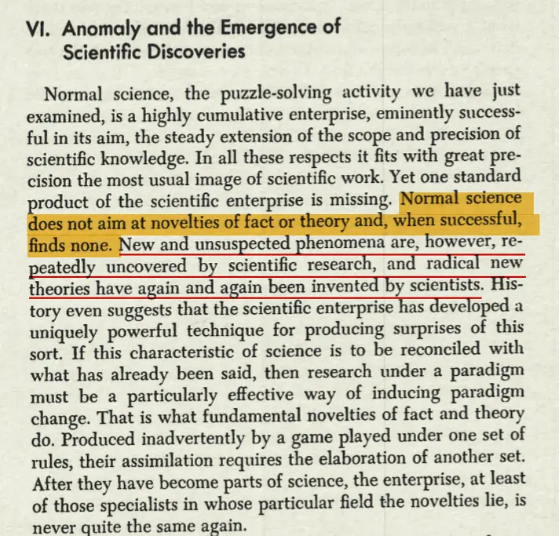

学者必须说出一些新的想法，并将它们和别人已经说过的联系起来。

- 所有人都对已经研究和论述了多年的研究感兴趣
- 既是因为这些论题重大、持续而普遍（人为什么自杀）
- 也因为被研究了这么久，已经制造了一种科学谜题（小世界的假设）

> Michael Schudson: 把研究和文献联系起来，用那些已经被接受的理论，得出看似不可能的结论。

你不需要从头开始创造所有的内容

- 其他人已经做过一些相关的题目
- 你只需要把它们塞进来放在正确的位置
- 要一直收集这类预制的模块

文献的坏处是对其关注太多可能会毁了你自己的论述。

- 文献控制了对问题的思考方式
  - 例如，文献常常将吸毒者看做不正常的人。网瘾患者也常常被这样看待。
  - 贝克尔1953年将吸大麻者看作是一个刚遭遇了不同经历的正常人
    - 他们会经历重新定义吸大麻经历的过程
  - 忽略了一个更有趣的问题：人们如何学会定义自己的内在经历
    - 例如：饿了、肥胖

### 窍门：用自己的语言来表达

当你感觉无法用自己的语言来表达意思时，你应该警惕自己不要被文献压垮了。

# 第九章 用计算机写作

电脑的真正优越之处在于它克服了写作的物理阻力！

- 写作是一项智力活动，是概念性的，它处理的是思想和情感。
- 但写作也有物质性，具有身体的一面
  - 腰酸背痛
  - 把打字说成写作
  - 作家 vs 打字员

## 窍门：不断拆分和重组

电脑的真正优越之处在于它克服了写作的物理阻力！

- 改写文章不再以为着用剪刀剪切用浆糊粘贴。
- 通过电脑书写思考变得容易多了
  - 可以随时将一个想法插入任意位置。
- 字数统计：即时反馈
- 存储
- 绘图
- 写提纲
  - 设置N级标题作为文章框架
  - 在大纲、论题和文字之间来回反复
- 参考书目
- 关键词检索、查找和替换

# 第十章 结语

写于1986年

- 想在第一稿就把文章写对，就什么也写不了了
- 无须担心初稿的缺陷，你可以反复修改
- 意志和努力不可或缺，但仍需敞开自我接受他人的批评
- 写任何东西都可以减少写作的挑战
- 行动和互动胜过孤独的思考
- 由易到难、步步为营

续结语 2007年

当我刚成为社会学家时，我曾对自己说：如果教学和科研成为麻烦，大不了我再回到酒吧里靠弹钢琴赚钱。

- 我再也回不去了，如今已经不再有小乐队，而是换上大屏幕电视了
- 社会学是一个好得多的职业，我从未后悔。
- 指标性腐败
- 引用数量为王
  - 标题长度变长、方便被引
- 名气影响编辑的判断

你可以发表几乎任何文章，只要你愿意在旗舰刊物之外的地方发表它。

- 书籍出版商更关注如何取悦读者

我不觉得自己能给大家带来灵感，但在最后我会试着带给大家一些希望。祝你们好远。